# Compito di Statistica

Scrivere in stampatello

| COGNOME | $\LARGE\square$ | $\LARGE\square$ | $\LARGE\square$ | $\LARGE\square$ | $\LARGE\square$ | $\LARGE\square$ | $\LARGE\square$ | $\LARGE\square$ | $\LARGE\square$ | $\LARGE\square$ | $\LARGE\square$ | $\LARGE\square$ | $\LARGE\square$ | $\LARGE\square$ | $\LARGE\square$ | $\LARGE\square$ | $\LARGE\square$ | $\LARGE\square$ | $\LARGE\square$ | $\LARGE\square$ |
| --- | --- | --- | --- | --- | --- | --- | --- | --- | --- | --- | --- | --- | --- | --- | --- | --- | --- | --- | --- | --- |
| NOME | $\LARGE\square$ | $\LARGE\square$ | $\LARGE\square$ | $\LARGE\square$ | $\LARGE\square$ | $\LARGE\square$ | $\LARGE\square$ | $\LARGE\square$ | $\LARGE\square$ | $\LARGE\square$ | $\LARGE\square$ | $\LARGE\square$ | $\LARGE\square$ | $\LARGE\square$ | $\LARGE\square$ | $\LARGE\square$ | $\LARGE\square$ | $\LARGE\square$ | $\LARGE\square$ | $\LARGE\square$ |
| Matricola | $\LARGE\square$ | $\LARGE\square$ | $\LARGE\square$ | $\LARGE\square$ | $\LARGE\square$ | $\LARGE\square$ | $\LARGE\square$ | $\LARGE\square$ | $\LARGE\square$ | $\LARGE\square$ | $\LARGE\square$ | $\LARGE\square$ | $\LARGE\square$ | $\LARGE\square$ | $\LARGE\square$ | $\LARGE\square$ | $\LARGE\square$ | $\LARGE\square$ | $\LARGE\square$ | $\LARGE\square$ |
| CDL | $\LARGE\square$ | $\LARGE\square$ | $\LARGE\square$ | $\LARGE\square$ | $\LARGE\square$ |  |  |  |  |  |  |  |  |  |  |  |  |  |  |  |

### Esercizio 1

Su un campione di $160$ famiglie della provincia di Milano è stato rilevata la spesa annua per le vacanze (espresso in migliaia di euro). Qui di seguito la distribuzione delle frequenze cumulate:

| $[\text{x}_j,$ | $\text{x}_{j+1})$ | $F_j$ |
| --- | --- | --- |
| 0.0 | 1.5 | 0.4438 |
| 1.5 | 3.0 | 0.6688 |
| 3.0 | 8.0 | 0.8938 |
| 8.0 | 20.0 | 1.0000 |

1.a **(Punti 14)** Disegnare l’istogramma di densità percentuale.

| $[\text{x}_j,$ | $\text{x}_{j+1})$ | $n_j$ | $f_j$ | $b_j$ | $h_j$ |
| --- | --- | --- | --- | --- | --- |
| 0.0 | 1.5 | 71 | 0.4438 | 1.5 | 29.5833 |
| 1.5 | 3.0 | 36 | 0.2250 | 1.5 | 15.0000 |
| 3.0 | 8.0 | 36 | 0.2250 | 5.0 | 4.5000 |
| 8.0 | 20.0 | 17 | 0.1062 | 12.0 | 0.8854 |
|  |  | 160 | 1.0000 | 20.0 |  |

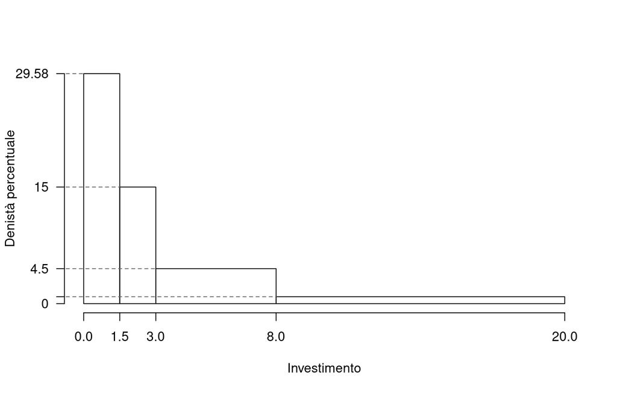

1.b **(Punti 3)** Quante famiglie spendono meno di 5 mila euro all’anno?

$$\begin{eqnarray*}
\%(X< 5 ) &=& f_{ 1 }\times 100+f_{ 2 }\times 100 +( 5
- 3 )\times h_{ 3 } \\
&=& ( 0.4438 )\times 100+( 0.225 )\times 100 +( 2
)\times 4.5 \\
&=& 0.7588 \times(100) \\
\#(X< 5 ) &\approx& 121
\end{eqnarray*}$$

1.c **(Punti 2)** Che relazione dobbiamo aspettarci tra media, mediana e moda?

1.d **(Punti 2)** La spesa media è pari a $\bar x=3.4838$, mentre la SD è pari a $SD=3.9497$. Se ogni famiglia spendesse 2 mila euro in più all’anno, quanto varrebbero la media e la SD dei dati trasformati?

### Esercizio 2

2.a **(Punti 14)** Si lancia una moneta perfetta 4 volte. Sia $X$ la variabile casuale che conta il numero di Teste su 4 lanci. Calcolare la probabilità che $X\leq 2$.

$$\begin{eqnarray*}
P( X \leq 2 ) &=& \binom{ 4 }{ 0 } 0.5 ^{ 0 }(1- 0.5 )^{ 4
- 0 }+\binom{ 4 }{ 1 } 0.5 ^{ 1 }(1- 0.5 )^{ 4 - 1 }+\binom{ 4 }{ 2 }
0.5 ^{ 2 }(1- 0.5 )^{ 4 - 2 } \\ &=&
0.0625+0.25+0.375 \\ &=& 0.6875
\end{eqnarray*}$$

2.b **(Punti 3)** Sia lancia una seconda moneta perfetta 3 volte. Sia $Y$ la variabile casuale che conta il numero di Teste su 3 lanci. Calcolare la probabilità che $X+Y=3$.

Siccome $X+Y\sim\text{Binom(4+3,0.5)}$, allora
$$\begin{eqnarray*}
P( X+Y = 3 ) &=& \binom{ 7 }{ 3 } 0.5 ^{ 3 }(1- 0.5 )^{ 7
- 3 } \\ &=& 35 \times 0.5 ^{ 3 }(1- 0.5 )^{ 4 }
\\ &=& 0.2734
\end{eqnarray*}$$

2.c **(Punti 2)** Se $P(A)=0.4$ e $P(B)=0.8$, $A$ e $B$ possono essere incompatibili? Perché?

Se $A$ e $B$ fossero incompatibili, allora $A\cap B=\emptyset$ allora $P(A\cup B)=P(A)+P(B)$, ma essendo $0.4+0.8=1.2>1$ allora $A\cap B\neq\emptyset$

2.d **(Punti 2)** Cosa significa che la funzione di ripartizione è continua a destra?

### Esercizio 3

3.a **(Punti 14)** Una catena di montaggio a ciclo continuo produce ogni giorno un numero di pezzi variabile, con una media pari a $\mu=1.3$ mila pezzi al giorno e una varianza di $\sigma^2=8.1$.

Calcolare la probabilità che la media annuale ($n=365$) sia inferiore a 1.2 (mila) pezzi prodotti.

**Teorema del Limite Centrale (media VC qualunque)**

Siano $X_1$,…,$X_n$, $n=365$ VC IID, tc $E(X_i)=\mu=1.3$ e $V(X_i)=\sigma^2=8.1,\forall i$, posto:
$$\bar X=\frac{S_n}n =\frac{X_1 + ... + X_n}n$$
allora:
$$\begin{eqnarray*}
\bar X & \mathop{\sim}\limits_{a}& N(\mu,\sigma^2/n) \\
&\sim & N\left(1.3,\frac{8.1}{365}\right) \\
&\sim & N(1.3,0.02219)
\end{eqnarray*}$$
$$\begin{eqnarray*}
P( \bar X < 1.2 )
&=& P\left( \frac { \bar X - \mu }{ \sqrt{\sigma^2/n}
} < \frac { 1.2 - 1.3 }{\sqrt{ 0.02219 }} \right) \\
&=& P\left( Z < -0.67 \right) \\
&=& 1-\Phi( 0.67 ) \\ &=& 0.2514
\end{eqnarray*}$$

### Esercizio 4

4.a **(Punti 3)** Si consideri il modello normale $X\sim N(\mu,\sigma^2)$. Sia $\hat\mu$ lo stimatore di massima verosimiglianza per $\mu$

$$\hat\mu = \frac 1n \sum_{i=1}^n X_i$$

Estratti $n=25$ dati si è ottenuto $\sum_{i=1}^n x_i = 45$ e $\sum_{i=1}^n x_i^2 = 105$. Ricavare il suo *Standard Error* teorico e quello stimato.

4.b **(Punti 3)** Sia $h$ uno stimatore per $\theta$, cosa significa che $h$ è consistente?

4.c **(Punti 3)** Definire la significatività e la potenza di un test.

4.d **(Punti 3)** Un responsabile delle risorse umane sta conducendo uno studio sull’associazione tra il tipo di formazione ricevuta e la performance lavorativa. Ha somministrato un questionario a 260 dipendenti, chiedendo loro di indicare la propria performance lavorativa (Alta, Media, Bassa) e il tipo di formazione ricevuta (Tecnica, Manageriale, Soft Skills). L’obiettivo è determinare se c’è un’associazione tra il tipo di formazione ricevuta e la performance lavorativa.

|  | Performance Lavorativa Alta | Performance Lavorativa Media | Performance Lavorativa Bassa |
| --- | --- | --- | --- |
| **Tipo di Formazione** |  |  |  |
| Tecnica | 30 | 15 | 20 |
| Manageriale | 20 | 25 | 40 |
| Soft Skills | 45 | 30 | 35 |

### Esercizio 5

In uno studio sull’efficacia dell’investimento pubblicitario sono stati rilevati, per $n=50$ aziende si sono rilevati l’incremento di spesa in pubblicità ($X$) e l’incremento di utile ($Y$) nell’ultimo quinquennio. Si osservano le seguenti statistiche, $\sum_{i=1}^{50}x_i=690.2239$, $\sum_{i=1}^{50}y_i=360.9573$, $\sum_{i=1}^{50}x_i^2=13373.9607$, $\sum_{i=1}^{50}y_i^2=3864.8997$ e $\sum_{i=1}^{50}x_iy_i=6692.1265$.

5.a **(Punti 14)** Stimare il modello di regressione dove $Y$ viene spiegata da $X$.

$$\begin{eqnarray*}
\bar x &=&\frac 1 n\sum_{i=1}^n x_i = \frac {1}{ 50
} 690.2239 = 13.8 \\
\bar y &=&\frac 1 n\sum_{i=1}^n y_i = \frac {1}{ 50
} 360.9573 = 7.219 \\
\hat\sigma_X^2&=&\frac 1 n\sum_{i=1}^n x_i^2-\bar
x^2=\frac {1}{ 50 } 13374 - 13.8045 ^2= 76.92 \\
\hat\sigma_Y^2&=&\frac 1 n\sum_{i=1}^n y_i^2-\bar
y^2=\frac {1}{ 50 } 3865 - 7.2191 ^2= 25.18 \\
\text{cov}(X,Y)&=&\frac 1 n\sum_{i=1}^n x_i~y_i-\bar
x\bar y=\frac {1}{ 50 } 6692 - 13.8045 \cdot 7.2191 = 34.19 \\
\hat\beta_1 &=&
\frac{\text{cov}(X,Y)}{\hat\sigma_X^2} \\
&=& \frac{ 34.19 }{ 76.92 } = 0.4445 \\
\hat\beta_0 &=& \bar y - \hat\beta_1 \bar x\\
&=& 7.219 - 0.4445 \times 13.8045 = 1.084
\end{eqnarray*}$$

5.b **(Punti 3)** Qual è la percentuale di varianza spiegata dal modello?

$$\begin{eqnarray*}
r&=&\frac{\text{cov}(X,Y)}{\sigma_X\sigma_Y}=\frac{ 34.19 }{
8.77 \times 5.018 }= 0.7768 \\r^2&=& 0.6034 < 0.75
\end{eqnarray*}$$
Il modello **non** si adatta bene ai dati.

5.c **(Punti 14)** Testare l’ipotesi che l’intercetta sia uguale a zero contro l’alternativa che sia diversa da zero.

$\fbox{A}$ FORMULAZIONE DELLE IPOTESI

$$\begin{cases}
H_0: \beta_0 = \beta_{0;H_0}=0 \\
H_1: \beta_0 \neq \beta_{0;H_0}=0
\end{cases}$$

$\fbox{B}$ SCELTA E CALCOLO STATISTICA-TEST, $T$ Test su un coefficiente di regressione: $\Rightarrow$ t-Test.

$$\begin{eqnarray*}
\frac{\hat\beta_{ 0 } - \beta_{ 0 ;H_0}} {\widehat{SE(\hat\beta_{ 0
})}}&\sim&t_{n-2}\\
t_{\text{obs}}
&=& \frac{ ( 1.084 - 0 )} { 0.8506 }
= 1.274 \, .
\end{eqnarray*}$$

$\fbox{C}$ CONCLUSIONE

La siginficatitività è $\alpha=0.05$, dalle tavole osserviamo $t_{50-2;0.025}=2.0106$.

Essendo $|t_\text{obs}|=1.2739<t_{50-2;0.025}=2.0106$ allora **non** rifiuto $H_0$ al 5%.

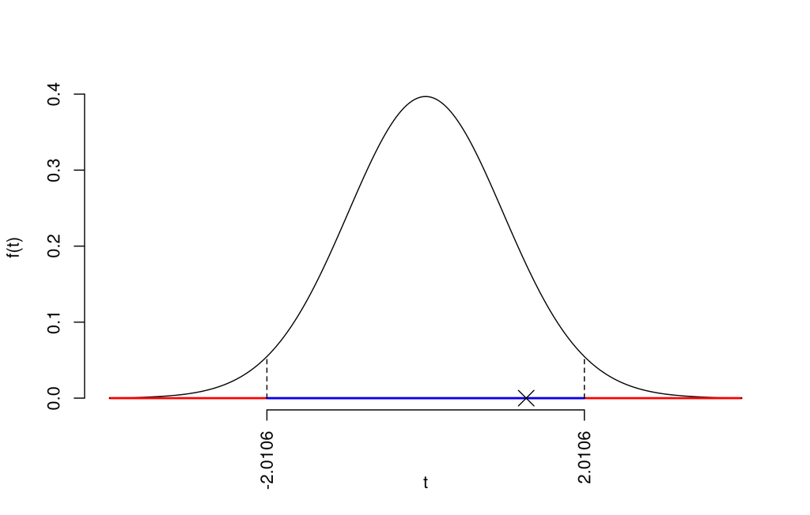

Il $p_{\text{value}}$ è

$$p_{\text{value}} =
P(|T_{50-2}|>|1.27|)=2P(T_{50-2}>1.27)=0.208849$$

Attenzione il calcolo del $p_\text{value}$ con la $T$ è puramente illustrativo e non può essere riprodotto senza una calcolatrice statistica adeguata.
$$0.1 < p_\text{value}= 0.208849 \leq 1$$

5.d **(Punti 2)** Interpretare il diagramma dei residui.

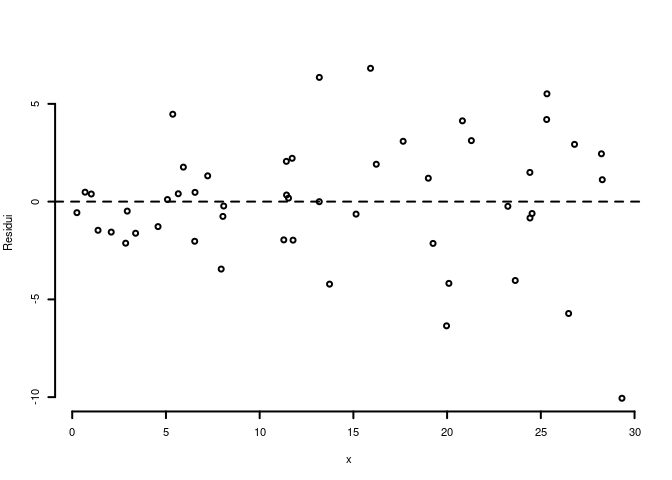

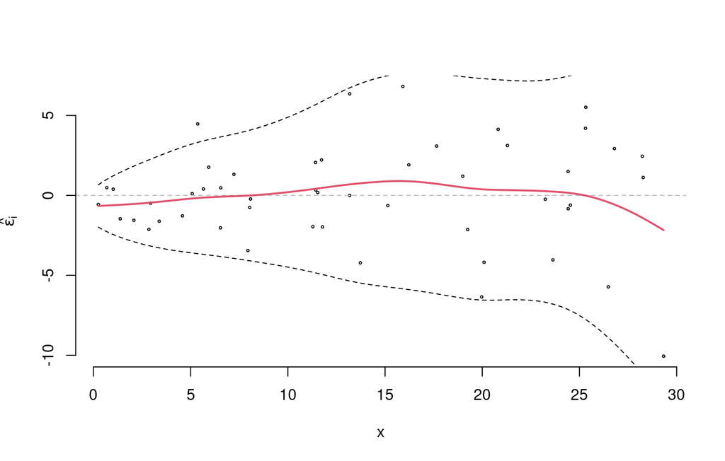

5.e **(Punti 2)** Perché una previsione per $x=15$ è più affidabile di una per $x=50$?